# STAT 689 Homework 11

## Rohan Tiwari

### This concerns the pig weight data. When fitting a spline, please use k = 4 or k = 3.

```r
library(HRW)
library(gamm4)
setwd("~/tamu/MS-STAT-2022/689-flexible-regression")
pigs = read.csv(file="pigWeights.csv")
```

### 1. Consider the pig weight data. Use the program Indiana_BLUP.R, as a guide. However, set numIntKnotsGbl = 6 and numIntKnotsGrp = 3

### 1a. How many pigs are in the model?

```r
# Number of subjects
numGrp = length(unique(pigs$id.num))
cat('Number of pigs is:', numGrp)
```

```
## Number of pigs is: 48
```

### 1b. Using native code, as in the program, fit the random function model, and display summary statistics from that fit

```r
weight = pigs$weight
num.weeks = pigs$num.weeks
# Get ID numbers that are consecutive from
# 1 to n. I have no idea why you need to do this
###################################################
#idnumBM = rep(NA,length(pigs$id.num))
# Ids are sequential
idnumBM = pigs$id.num
# Total number of observations
numObs = length(pigs$id.num)
# Number of knots at the population level
numIntKnotsGbl = 6
# O'Sullivan Basis Functions at the population level
intKnotsGbl = quantile(unique(num.weeks),
                       seq(0,1,length=numIntKnotsGbl+2))[-c(1,numIntKnotsGbl+2)]
range.num_weeks = c(5.5,20)
range.num_weeks = c(min(num.weeks)-0.01, max(num.weeks)+0.01)
Zgbl = ZOSull(num.weeks,range.x=range.num_weeks,intKnots=intKnotsGbl)
# Number of knots at the subject level. Should be less than the
# number of knots at the population level
numIntKnotsGrp = 3
# Basis functions for O'Sullivan splines at the
# individual level
intKnotsGrp = quantile(unique(num.weeks),
                       seq(0,1,length=numIntKnotsGrp+2))[-c(1,numIntKnotsGrp+2)]
Zgrp = ZOSull(num.weeks,range.x=range.num_weeks,intKnots=intKnotsGrp)
#####################################################################
# Set up the random effects structure and call lme
#
# See Lecture 18 for the explanation
#####################################################################
#
dummyId = factor(rep(1,numObs))
Zblock   = list(dummyId = pdIdent( ~ -1 + Zgbl),
               idnumBM = pdSymm( ~ num.weeks),
               idnumBM = pdIdent( ~ -1 + Zgrp))

blkMalGD = groupedData(weight ~ num.weeks|rep(1,length = numObs),
                        data = data.frame(weight,num.weeks,Zgbl,Zgrp,idnumBM))
fit      = lme(weight ~ num.weeks,data = blkMalGD,random = Zblock)
#####################################################################
# Get the summary
summary(fit)
```

```
## Linear mixed-effects model fit by REML
##   Data: blkMalGD
##        AIC      BIC    logLik
##   1643.095 1675.605 -813.5473
##
## Random effects:
##  Formula: ~-1 + Zgbl | dummyId
##  Structure: Multiple of an Identity
##            Zgbl1    Zgbl2    Zgbl3    Zgbl4    Zgbl5    Zgbl6    Zgbl7    Zgbl8
## StdDev: 1.086078 1.086078 1.086078 1.086078 1.086078 1.086078 1.086078 1.086078
##
##  Formula: ~num.weeks | idnumBM %in% dummyId
##  Structure: General positive-definite
##             StdDev    Corr
## (Intercept) 2.6305640 (Intr)
## num.weeks   0.6291706 -0.088
##
##  Formula: ~-1 + Zgrp | idnumBM %in% idnumBM %in% dummyId
##  Structure: Multiple of an Identity
##             Zgrp1     Zgrp2     Zgrp3     Zgrp4     Zgrp5  Residual
## StdDev: 0.6658473 0.6658473 0.6658473 0.6658473 0.6658473 0.8315139
##
## Fixed effects:  weight ~ num.weeks
##                 Value Std.Error  DF  t-value p-value
## (Intercept) 19.214836 0.3925976 383 48.94283       0
## num.weeks    6.236097 0.0925376 383 67.38988       0
##  Correlation:
##           (Intr)
## num.weeks -0.127
##
## Standardized Within-Group Residuals:
##          Min           Q1          Med           Q3          Max
## -3.057188693 -0.473455000 -0.001277873  0.447982305  2.502827552
##
## Number of Observations: 432
## Number of Groups:
##                             dummyId                idnumBM %in% dummyId
##                                   1                                  48
## idnumBM.1 %in% idnumBM %in% dummyId
##                                  48
```

### 1c. Plot the population mean function

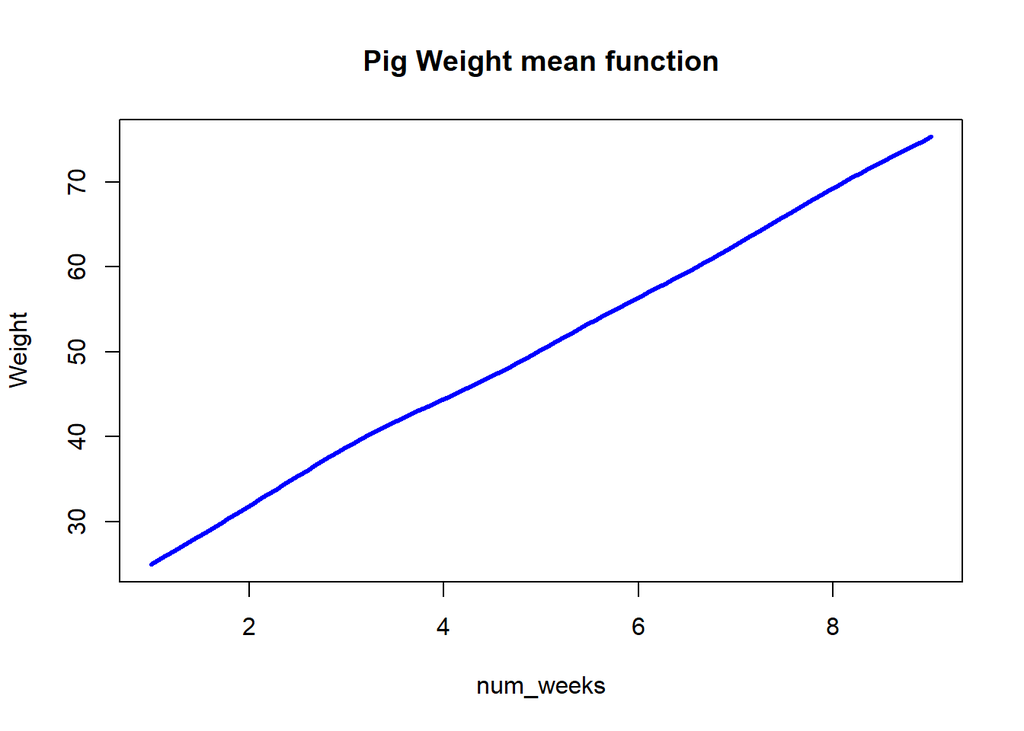

```r
#####################################################################
# Now we are going to get BLUPs and plot functions
# I will comment on most of the code
#####################################################################
# Size of grid on which to do the plotting
ng = 101
# Get the grid of ages
ageg = seq(range.num_weeks[1],range.num_weeks[2],length = ng)
# Form the design matrix for the linear part, which is a column
# of ones plus the grid of ages
Xg = cbind(rep(1,ng),ageg)
# Spline terms for the overall fit
Zgblg = ZOSull(ageg,range.x = range.num_weeks,
                intKnots = intKnotsGbl)
# Spline terms for the individual fits
Zgrpg = ZOSull(ageg,range.x = range.num_weeks,
                intKnots = intKnotsGrp)
# Get betahat, the intercept and the slope
betaHat = as.vector(fit$coef$fixed)
# Get uHat, the estimated spline coefficients for the
# overall fit
uHat = as.vector(fit$coef$random[[1]])
# Form the overall fit
fHatg = as.vector(Xg%*%betaHat + Zgblg%*%uHat)
# Now get the subject-specific estimated curves
curvEsts = vector("list",numGrp)
for (i in 1:numGrp)
{
  # T^he subject-specific terms for the slope
  # and intercept
  uLinHati = as.vector(fit$coef$random[[2]][i,])
  # The subject-specific terms for the spline coefficients
  uSplHati = as.vector(fit$coef$random[[3]][i,])
  # The individual function estimates
  ghati = Xg%*%uLinHati + Zgrpg%*%uSplHati
  curvEsts[[i]] = fHatg + ghati
}
plot(ageg,fHatg,type='l',lwd=3,col="blue",
     xlab="num_weeks",ylab="Weight",
     main="Pig Weight mean function")
```

### 1d. Plot the individual function fits for the first 8 pigs.

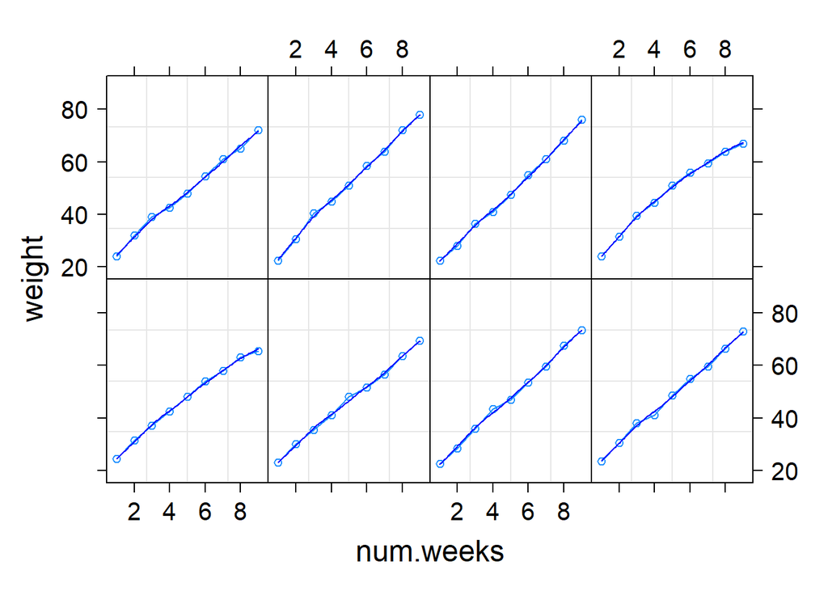

```r
library(lattice)

figBlkMalFit = xyplot(weight ~ num.weeks|idnumBM[idnumBM %in% 1:8],groups = idnumBM[idnumBM %in% 1:8],
                       data = pigs,
                       strip = FALSE,scales = list(cex = 1.25),
                       xlab = list("num.weeks",cex = 1.5),
                       ylab = list("weight",cex = 1.5),
                       as.table = TRUE,#layout = c(4,7),
                       panel = function(x,y,subscripts,groups)
                       {
                         panel.grid()
                         adolNum = idnumBM[subscripts][1]
                         panel.superpose(x,y,subscripts,groups,
                                         col = "dodgerblue",type = "b")
                         panel.xyplot(ageg,curvEsts[[adolNum]],
                                      col = "blue",type = "l")
                       })
#pdf('BLUP_Fits_At_the_Individual_Level.pdf')
plot(figBlkMalFit)
```

### 1e. Fit the random function (not random intercept) model using gamm4::gamm4. How does this compare to your answer in (b) above. Please be short: I do not mean this as a big deal

```r
fit_gamm =  gamm4::gamm4(weight ~
                            s(I(num.weeks), k=7, bs="cr")
                         + s(I(num.weeks), as.factor(id.num), k=5, bs="fs",
                             xt=list(bs="cr")),data=pigs)
summary(fit_gamm$mer)
```

```
## Linear mixed model fit by REML ['lmerMod']
##
## REML criterion at convergence: 1662.9
##
## Scaled residuals:
##      Min       1Q   Median       3Q      Max
## -3.08106 -0.42739 -0.01108  0.40790  2.67851
##
## Random effects:
##  Groups   Name                              Variance  Std.Dev.
##  Xr.0     s(I(num.weeks),as.factor(id.num))   7.50217  2.7390
##  Xr.2     s(I(num.weeks),as.factor(id.num))  80.33324  8.9629
##  Xr.1     s(I(num.weeks),as.factor(id.num)) 536.49191 23.1623
##  Xr       s(I(num.weeks))                     0.02944  0.1716
##  Residual                                     0.75652  0.8698
## Number of obs: 432, groups:  Xr.0, 144; Xr.2, 48; Xr.1, 48; Xr, 5
##
## Fixed effects:
##                     Estimate Std. Error t value
## X(Intercept)         50.4051     0.4934  102.15
## Xs(I(num.weeks))Fx1 -43.8796     1.0177  -43.12
##
## Correlation of Fixed Effects:
##             X(Int)
## Xs(I(n.))F1 -0.706
```

Residual std.dev for native and gamma4 is slightly different (almost same). The sigma_grp std.dev is much different for gamm4 and native code.

### 2. Run a random intercept model on these data. I think you can get the answers I want using either mgcv::gamm or gamm4::gamm4. I believe that the between-subject variability for weeks 1-5 is smaller than that for weeks 6-9. Run the random intercept model separately for these two time periods and see if you agree with me. You are likely to have more luck on this with mgcv::gamm, and you may need to set k = 3 to get an answer.

```r
pigs1_5 = pigs[(pigs$num.weeks <=5),]
pigs6_9 = pigs[(pigs$num.weeks >= 6),]

fitpigs1_5 = gamm4(weight ~ s(I(num.weeks),k=4,bs="cr"),
             random= ~(1|id.num),data = pigs1_5)
fitpigs6_9 = gamm4(weight ~ s(I(num.weeks),k=4,bs="cr"),
             random= ~(1|id.num),data = pigs6_9)
```

### 2a. Show you results (not the plots).

```r
summary(fitpigs1_5$mer)
```

```
## Linear mixed model fit by REML ['lmerMod']
##
## REML criterion at convergence: 1003.7
##
## Scaled residuals:
##     Min      1Q  Median      3Q     Max
## -4.1567 -0.5546  0.0322  0.5046  3.5117
##
## Random effects:
##  Groups   Name            Variance Std.Dev.
##  id.num   (Intercept)     10.25183 3.2018
##  Xr       s(I(num.weeks))  0.08126 0.2851
##  Residual                  1.95979 1.3999
## Number of obs: 240, groups:  id.num, 48; Xr, 2
##
## Fixed effects:
##                     Estimate Std. Error t value
## X(Intercept)         38.0437     0.4709   80.79
## Xs(I(num.weeks))Fx1  18.7463     0.1918   97.73
##
## Correlation of Fixed Effects:
##             X(Int)
## Xs(I(n.))F1 0.000
```

```r
summary(fitpigs6_9$mer)
```

```
## Linear mixed model fit by REML ['lmerMod']
##
## REML criterion at convergence: 893.2
##
## Scaled residuals:
##     Min      1Q  Median      3Q     Max
## -2.7283 -0.5548  0.0605  0.5713  3.2471
##
## Random effects:
##  Groups   Name            Variance Std.Dev.
##  id.num   (Intercept)     26.137   5.112
##  Xr       s(I(num.weeks))  0.000   0.000
##  Residual                  2.401   1.549
## Number of obs: 192, groups:  id.num, 48; Xr, 2
##
## Fixed effects:
##                     Estimate Std. Error t value
## X(Intercept)         65.8568     0.7463   88.24
## Xs(I(num.weeks))Fx1  14.1222     0.2236   63.15
##
## Correlation of Fixed Effects:
##             X(Int)
## Xs(I(n.))F1 0.000
```

### Please make sure to look at Wood_Example.R in the Cox_Regression folder within Data_Sets.

The data set Stat689_homework11_Actual.csv within the folder Homework11 has the following variables; colon_cc: = 0 if the person does not develop colon cancer, i.e., is censored. = 1 otherwise nonsmoker: = 1 if the person is a nonsmoker, = 0 if they smoke. age: Self-explanatory. bmi: Self-explanatory. personyrs: Time since being diagnosed with colon cancer.

All problems assume that the binary variable zz$nonsmoker is in the model.

```r
colonCancer = read.csv(file="Stat689_homework11_Actual.csv")
head(colonCancer)
```

```
##   X colon_cc nonsmoker    age      bmi personyrs
## 1 1        1         1 63.337 25.85026     5.155
## 2 2        1         1 70.245 26.64942     4.507
## 3 3        1         0 57.979 29.55649     1.708
## 4 4        1         1 66.916 30.30010     2.130
## 5 5        1         1 68.936 25.02049     2.119
## 6 6        1         1 71.302 23.61961     2.267
```

### 3. In the original data set, which for want of imagination I call zz, there were a number of subjects with column 4 = 0, or bmi = 0. I changed all these to NA by the command is.na(zz[,4]) = !zz[,4]. Like the trained monkey I am in R, I just looked this up.

```r
is.na(colonCancer[,4]) = !colonCancer[,4]
```

### 4. Now delete all subjects that have any missing data. You might look up na.omit. How many subjects are left?

```r
colonCancer = na.omit(colonCancer)
cat('Number of subjects left:', nrow(colonCancer))
```

```
## Number of subjects left: 6559
```

### 5. What percentage developed colon cancer?

```r
pctcc = 100*sum(colonCancer$colon_cc) / nrow(colonCancer)
cat('% developed colon cancer is:', pctcc)
```

```
## % developed colon cancer is: 50.12959
```

### 6. Run a Cox regression with age and bmi entering linearly. Show the output.

```r
ccfitLinear = gam(personyrs ~ age + bmi + nonsmoker,
                    weights = colon_cc ,
                    family = cox.ph , data = colonCancer)
summary(ccfitLinear)
```

```
##
## Family: Cox PH
## Link function: identity
##
## Formula:
## personyrs ~ age + bmi + nonsmoker
##
## Parametric coefficients:
##            Estimate Std. Error z value Pr(>|z|)
## age        0.050469   0.003453  14.615  < 2e-16 ***
## bmi        0.026121   0.004216   6.196 5.79e-10 ***
## nonsmoker -0.178054   0.035111  -5.071 3.95e-07 ***
## ---
## Signif. codes:  0 '***' 0.001 '**' 0.01 '*' 0.05 '.' 0.1 ' ' 1
##
##
## Deviance explained =  1.7%
## -REML =  27307  Scale est. = 1         n = 6559
```

### 7. Describe the results in problem 1, using statistical significance. Remember, negative values of a coefficient for zz$nonsmoker means that nonsmokers are less likely to develop colon cancer.

Age is highly significant. The coefficient estimate is positive (0.050469). The risk of colon cancer increases with age on an average. bmi is highly significant. The coefficient estimate is positive (0.026121). The risk of colon cancer increases with bmi on an average. nonsmoker is highly significant. The coefficient estimate is negative (-0.178054). The risk of colon cancer is higher for smoker than nonsmoker.

### 8. Now run a Cox regression with age and bmi entering as smooths. Show your output.

```r
ccfitgam = gam(personyrs ~ s(age) + s(bmi) + nonsmoker
                 , weights = colon_cc , family = cox.ph , data = colonCancer)
summary(ccfitgam)
```

```
##
## Family: Cox PH
## Link function: identity
##
## Formula:
## personyrs ~ s(age) + s(bmi) + nonsmoker
##
## Parametric coefficients:
##           Estimate Std. Error z value Pr(>|z|)
## nonsmoker -0.17837    0.03511   -5.08 3.78e-07 ***
## ---
## Signif. codes:  0 '***' 0.001 '**' 0.01 '*' 0.05 '.' 0.1 ' ' 1
##
## Approximate significance of smooth terms:
##          edf Ref.df Chi.sq p-value
## s(age) 2.358  2.952 210.79  <2e-16 ***
## s(bmi) 1.043  1.085  37.59  <2e-16 ***
## ---
## Signif. codes:  0 '***' 0.001 '**' 0.01 '*' 0.05 '.' 0.1 ' ' 1
##
## Deviance explained = 1.77%
## -REML =  27302  Scale est. = 1         n = 6559
```

### 9. What is statistically significant?

Splines on age and bmi are statistically significant. Also, nonsmoker is statistically significant.

### 10. Try to compare the models in Problems 4 and 5 using your favorite method. See my caveat below.

```r
anova(ccfitLinear, ccfitgam , test = "Chisq")
```

```
## Analysis of Deviance Table
##
## Model 1: personyrs ~ age + bmi + nonsmoker
## Model 2: personyrs ~ s(age) + s(bmi) + nonsmoker
##   Resid. Df Resid. Dev     Df Deviance Pr(>Chi)
## 1    6556.0      54591
## 2    6553.3      54584 2.6724   7.0893  0.05357 .
## ---
## Signif. codes:  0 '***' 0.001 '**' 0.01 '*' 0.05 '.' 0.1 ' ' 1
```

Spline model is significant so smoothing the terms is a good idea but if we consider significance at 0.05 that spline model is not significant and smoothing terms is not a good idea.

### 11. Pick a single person and plot his/her survival curves and pointwise confidence intervals for the model in question 8.

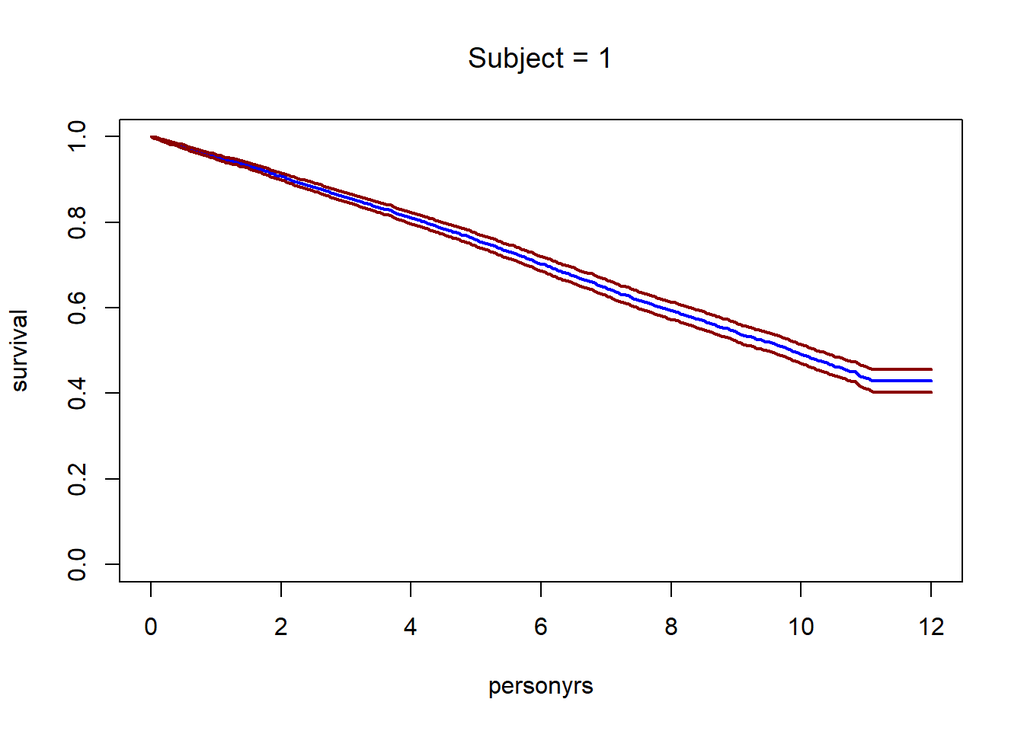

```r
# What subject are you interested in
# Set subject number
#pdf("Survival_Probabilities_Subject_66.pdf")
subjectnum = 1
par(mfrow=c(1,1))
# Number of time point in the grid
np = 300
# Get the data frame for your chosen subject
newd = data.frame(matrix(0,np,0))
for (n in names(colonCancer)){
  newd[[n]] = rep(colonCancer[[n]][subjectnum],np)
}
newd$personyrs <- seq(0, 12, length=np)
## predict and plot the survival function...
fv = predict(ccfitgam,newdata=newd,type="response",se=TRUE)
plot(newd$personyrs,fv$fit,type="l", xlim=c(0, 12), ylim=c(0, 1),xlab="personyrs",
     ylab="survival",lwd=2,col="blue",
     main = substitute(paste("Subject = ",m),list(m = subjectnum)))
## Add intervals based on cumulative hazard s.e...
# This appears to be correct, but involves heavy theory
se = fv$se.fit/fv$fit
lines(newd$personyrs,exp(log(fv$fit)+2*se),col="red4",lwd=2)
lines(newd$personyrs,exp(log(fv$fit)-2*se),col="red4",lwd=2)
```